# inbasketosis

```r
# Load libraries
library(readxl)
library(readr)
library(dplyr)
library(tidyr)
library(stringr)
library(janitor)

# Load raw data
messages <- read_excel("Epic Signal PEP Data.xlsx", sheet = "Messages")
time <- read_excel("Epic Signal PEP Data.xlsx", sheet = "Time")
raw <- bind_rows(messages, time)

# Initial exploration
str(raw)
```

```
## tibble [2,880 × 15] (S3: tbl_df/tbl/data.frame)
##  $ DE_ID  : num [1:2880] 6454804 6454804 6454804 6454804 6454804 ...
##  $ Grouper: chr [1:2880] "PHYSICIAN + PSYCHIATRIST" "PHYSICIAN + PSYCHIATRIST" "PHYSICIAN + PSYCHIATRIST" "PHYSICIAN + PSYCHIATRIST" ...
##  $ Metric : chr [1:2880] "Count Of In Basket Minutes" "Minutes In In Basket Per Day" "Minutes In In Basket Per Appointment" "Count Of Patient Call Messages Recieved" ...
##  $ 24-Jul : num [1:2880] NA NA NA NA NA NA NA NA NA NA ...
##  $ 24-Aug : num [1:2880] 11 2.1 0 0 0 0 0 0 0 0 ...
##  $ 24-Sep : num [1:2880] 6 0.8 0 0 0 0 0 0 0 0 ...
##  $ 24-Oct : num [1:2880] 9 1.2 0 0 0 0 0 0 0 0 ...
##  $ 24-Nov : num [1:2880] 21 1.4 0 0 0 0 0 0 0 0 ...
##  $ 24-Dec : num [1:2880] 5 1.2 0 0 0 0 0 0 0 0 ...
##  $ 25-Jan : num [1:2880] 24 1.8 0 0 0 0 0 0 0 0 ...
##  $ 25-Feb : num [1:2880] 8 0.8 0 0 0 0 0 0 0 0 ...
##  $ 25-Mar : num [1:2880] 22 1.6 0 0 0 0 0 0 0 0 ...
##  $ 25-Apr : num [1:2880] 15 1.5 0 0 0 0 0 0 0 0 ...
##  $ 25-May : num [1:2880] 28 4.7 0 0 0 0 0 0 0 0 ...
##  $ 25-Jun : num [1:2880] 10 1.1 0 0 0 1 0 5.1 0 0 ...
```

```r
head(raw)
```

```
## # A tibble: 6 × 15
##     DE_ID Grouper   Metric `24-Jul` `24-Aug` `24-Sep` `24-Oct` `24-Nov` `24-Dec`
##     <dbl> <chr>     <chr>     <dbl>    <dbl>    <dbl>    <dbl>    <dbl>    <dbl>
## 1 6454804 PHYSICIA… Count…       NA     11        6        9       21        5
## 2 6454804 PHYSICIA… Minut…       NA      2.1      0.8      1.2      1.4      1.2
## 3 6454804 PHYSICIA… Minut…       NA      0        0        0        0        0
## 4 6454804 PHYSICIA… Count…       NA      0        0        0        0        0
## 5 6454804 PHYSICIA… Count…       NA      0        0        0        0        0
## 6 6454804 PHYSICIA… Count…       NA      0        0        0        0        0
## # ℹ 6 more variables: `25-Jan` <dbl>, `25-Feb` <dbl>, `25-Mar` <dbl>,
## #   `25-Apr` <dbl>, `25-May` <dbl>, `25-Jun` <dbl>
```

```r
sort(unique(raw$Metric))
```

```
##  [1] "% Of Minutes On Saturday"
##  [2] "% Of Minutes On Sunday"
##  [3] "Average Days Until Patient Call Messages Marked Done"
##  [4] "Average Days Until Patient Medical Advice Request Message Marked Done"
##  [5] "Average Days Until Result Message Marked Done"
##  [6] "Average Days Until RX Auth Message Marked Done"
##  [7] "Count Of Appointments"
##  [8] "Count Of Days In Reporting Period"
##  [9] "Count Of Days In System"
## [10] "Count Of Days of Afterhours Activity"
## [11] "Count Of Days With Appointments"
## [12] "Count Of In Basket Minutes"
## [13] "Count Of Minutes Active On Unscheduled Days"
## [14] "Count Of Minutes Active Outside 7AM to 7PM"
## [15] "Count Of Minutes Active Outside Scheduled Time (30 Min Buffer)"
```

[output cut: 29 more lines]

```r
# Data cleaning
clean <- raw |>
  mutate(

    id = as.character(DE_ID),

    type = factor(
      case_when(
        Grouper == "PHYSICIAN + PSYCHIATRIST" ~ "MD",
        Grouper == "NURSE PRACTITIONER" ~ "NP",
        Grouper == "RESIDENT + FELLOW" ~ "RF",
        TRUE ~ Grouper
      ),
      levels = c("MD", "NP", "RF")
    ),

    group =
      factor(
        case_when(
          type %in% c("MD", "NP") ~ "Staff",
          TRUE ~ "Trainee"
          ),
          levels = c("Staff", "Trainee")
        ),

    # fix typo
    metric = str_replace(Metric, "Recieved", "Received")

  ) |>

  # remove duplicates
  distinct(id, type, metric, .keep_all = TRUE) |>

  # select columns
  select(id, type, group, metric, starts_with(c("24-", "25-")))

# Monthly aggregations
monthly <- clean |>
  summarise(
    across(
      starts_with(c("24-", "25-")),
      ~ as.numeric(case_when(str_starts(metric[1], "Count Of") ~ sum(.x, na.rm = TRUE),
                             TRUE ~ mean(.x, na.rm = TRUE)))),
    .by = metric
  )

# Pivot longer
long <- clean |>
  pivot_longer(starts_with(c("24-", "25-")), names_to = "month", values_to = "value")

# Pivot wider full dataset
full <- long |>
  pivot_wider(names_from = c("metric", "month"), values_from = "value") |> clean_names()

# Aggregate
aggregated <- clean |>
  rowwise() |>
  mutate(

    n_months = sum(!is.na(c_across(starts_with(c("24-", "25-"))))),

    tot = ifelse(str_starts(metric, "Count Of"),
                 sum(c_across(starts_with(c("24-", "25-"))), na.rm = TRUE),
                 mean(c_across(starts_with(c("24-", "25-"))), na.rm = TRUE)),

    max = max(c_across(starts_with(c("24-", "25-"))), na.rm = TRUE)
  ) |> ungroup() |>
  select(id, type, n_months, group, metric, tot, max)

# Pivot wider
wide <- aggregated |>
  pivot_wider(
    names_from = metric,
    values_from = c(tot, max),
    names_sep = "_"
  ) |>
  clean_names()

# Create final dataset with calculated fields
final <- wide |>
  transmute(

    # object identifiers
    id, type, group, n_months,

    # general denominators
    n_appt = tot_count_of_appointments,
    n_sch_day = tot_count_of_scheduled_days,
    n_sch_hrs = tot_scheduled_hours_per_day * n_sch_day,
    sys_min = tot_count_of_minutes_in_the_system,
    sys_hrs = sys_min / 60,

    # message counts
    n_mar = tot_count_of_patient_medical_advice_requests_messages_received,
    n_pcm = tot_count_of_patient_call_messages_received,
    n_res = tot_count_of_result_messages_received,
    n_rxa = tot_count_of_rx_auth_messages_received,
    n_msg = n_mar + n_pcm + n_res + n_rxa,

    # in-basket load
    ib_min = tot_count_of_in_basket_minutes,
    ib_hrs = ib_min / 60,
    ib_sys_ratio = ib_min / sys_min,
    ib_sch_ratio = ib_hrs / n_sch_hrs,

    # average days to complete (dtc)
    dtc_mar = tot_average_days_until_patient_medical_advice_request_message_marked_done,
    dtc_pcm = tot_average_days_until_patient_call_messages_marked_done,
    dtc_res = tot_average_days_until_result_message_marked_done,
    dtc_rxa = tot_average_days_until_rx_auth_message_marked_done,
    dtc_msg = (dtc_mar + dtc_pcm + dtc_res + dtc_rxa) / 4,

    # afterhours
    min_ost = tot_count_of_minutes_active_outside_scheduled_time_30_min_buffer,
    min_oud = tot_count_of_minutes_active_on_unscheduled_days,
    min_sat = tot_count_of_saturday_minutes,
    min_sun = tot_count_of_sunday_minutes,
    ah_min = min_ost + min_oud + min_sat + min_sun,
    ah_hrs = ah_min / 60,
    ah_sys_ratio = ah_min / sys_min,

    # minutes per appointment (mpa)
    ib_mpa = tot_minutes_in_in_basket_per_appointment,
    cr_mpa = tot_minutes_in_clinical_review_per_appointment,
    nl_mpa = tot_minutes_in_notes_letters_per_appointment,
    or_mpa = tot_minutes_in_orders_per_appointment,
    mpa = ib_mpa + cr_mpa + nl_mpa + or_mpa,

    # mpa proportions
    ib_mpa_pct = ifelse(ib_mpa > 0, ib_mpa / mpa, NA),
    cr_mpa_pct = ifelse(cr_mpa > 0, cr_mpa / mpa, NA),
    nl_mpa_pct = ifelse(nl_mpa > 0, nl_mpa / mpa, NA),
    or_mpa_pct = ifelse(or_mpa > 0, or_mpa / mpa, NA),

    # per month (pm)
    appt_pm = n_appt / n_months,
    sch_day_pm = n_sch_day / n_months,
    sch_hrs_pm = n_sch_hrs / n_months,
    sys_hrs_pm = sys_hrs / n_months,
    ah_hrs_pm = ah_hrs / n_months,
    ib_hrs_pm = ib_hrs / n_months,
    msg_pm = n_msg / n_months,
    mar_pm = n_mar / n_months,
    pcm_pm = n_pcm / n_months,
    res_pm = n_res / n_months,
    rxa_pm = n_rxa / n_months,

    # monthly max values
    appt_max = max_count_of_appointments,
    sch_day_max = max_count_of_scheduled_days,
    sch_hrs_max = max_scheduled_hours_per_day * sch_day_max,
    sys_hrs_max = max_count_of_minutes_in_the_system / 60,
    ah_hrs_max = (max_count_of_minutes_active_outside_scheduled_time_30_min_buffer +
                    max_count_of_minutes_active_on_unscheduled_days +
                    max_count_of_saturday_minutes +
                    max_count_of_sunday_minutes) / 60,
    ib_hrs_max = max_count_of_in_basket_minutes / 60,
    mar_max = max_count_of_patient_medical_advice_requests_messages_received,
    pcm_max = max_count_of_patient_call_messages_received,
    res_max = max_count_of_result_messages_received,
    rxa_max = max_count_of_rx_auth_messages_received,
    msg_max = mar_max + pcm_max + res_max + rxa_max

  )

# Save all datasets
if (!dir.exists("data")) {
  dir.create("data")
}
clean |> saveRDS("data/clean.rds")
monthly |> saveRDS("data/monthly.rds")
long |> saveRDS("data/long.rds")
full |> saveRDS("data/full.rds")
aggregated |> saveRDS("data/aggregated.rds")
wide |> saveRDS("data/wide.rds")
final |> saveRDS("data/final.rds")
```

# ════════════════════════════════════════════════════════════════

# Exploratory Data Analysis (EDA)

# ───────────────────────────────────────────────────────────────

```r
# Data preparation for analysis
```

Total Workload by Provider Type

| Provider | Appointments | Scheduled Hours | After-hours | In-Basket Hours | Messages Received |
| --- | --- | --- | --- | --- | --- |
| Attending | 16,296 | 11,791 | 2,725 | 920 | 20,149 |
| Nurse Practitioner | 2,414 | 1,547 | 1,152 | 216 | 1,758 |
| Resident/Fellow | 9,714 | 8,188 | 2,728 | 805 | 9,818 |
| Total | 28,424 | 21,526 | 6,605 | 1,941 | 31,725 |

### Table 2: Message Volume and Completion Metrics by Type

Message Volume and Completion Metrics by Type

| Metric | Medical Advice Request | Patient Call | Results | Rx Auth | All |
| --- | --- | --- | --- | --- | --- |
| Total - n (%) | 13841 (43.6%) | 6744 (21.3%) | 5220 (16.5%) | 5920 (18.7%) | 31725 (100%) |
| Per Month - mean (sd) | 19.6 (20.5) | 9.5 (11.9) | 7.4 (15.4) | 8 (12.3) | 44.4 (44.2) |
| Days To Complete - mean (sd) | 2.7 (3.7) | 3.2 (4.2) | 4.4 (6) | 0.4 (0.8) | 2.7 (3) |
| Correlation to In-Basket Hours* | 0.789 | 0.599 | 0.243 | 0.369 | 0.715 |
| Correlation to After-Hours* | 0.399 | 0.42 | 0.111 | 0.183 | 0.388 |

## Figures

### Figure 1: Barplot of ranked In-Basket Hours Per Month (colored by Provider Type)

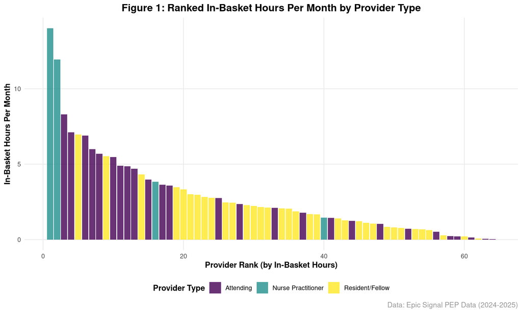

### Figure 2: Cumulative Ranked Share of In-Basket Hours by Providers (ranked by In-Basket Hours)

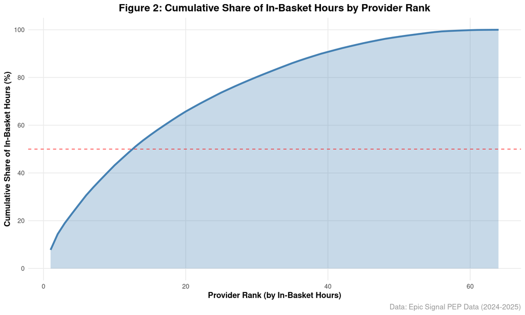

### Figure 3: Cumulative appointment equivalents by Providers (ranked by In-Basket Hours)

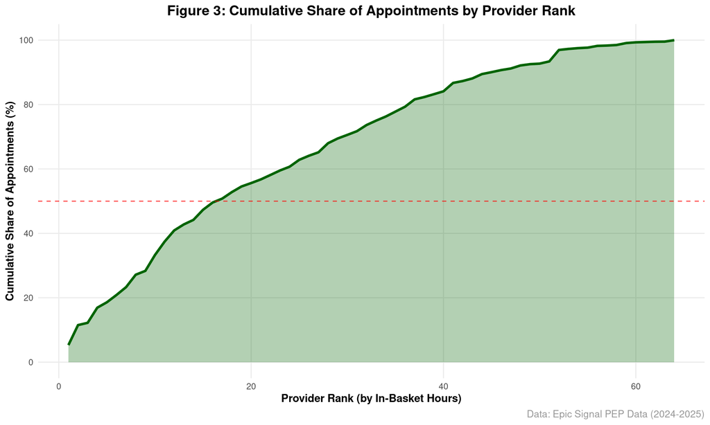

### Figure 4: Scatterplot of Total Messages Received per Month vs In-Basket Hours per Month (colored by Provider Type)

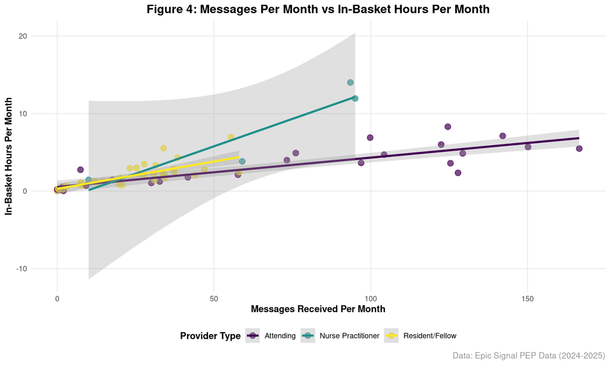

### Figure 5: In-Basket Minutes Per Appointment Vs. After-Hours Ratio

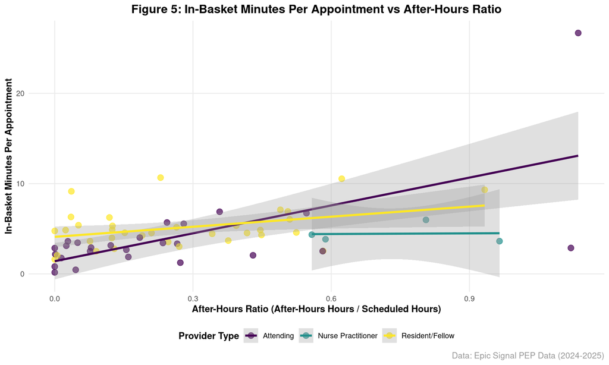

## Key Insights and Summary

```
## ## Summary Statistics by Provider Type
```

Summary Statistics by Provider Type

| Provider Type | N | Mean IB Hours/PM | SD IB Hours/PM | Mean Messages/PM | Mean AH Ratio |
| --- | --- | --- | --- | --- | --- |
| Attending | 26 | 3.1 | 2.5 | 66.9 | 0.247 |
| Nurse Practitioner | 4 | 7.8 | 6.1 | 64.4 | 0.729 |
| Resident/Fellow | 34 | 2.0 | 1.5 | 24.8 | 0.268 |

```
##
## ## Key Correlations
```

Key Correlations with In-Basket Hours

| Metric | Correlation |
| --- | --- |
| Messages vs In-Basket Hours | 0.715 |
| After-Hours vs In-Basket Hours | 0.775 |
| Appointments vs In-Basket Hours | 0.756 |
| Scheduled Hours vs In-Basket Hours | 0.678 |

### Key Findings:

1. **Provider Workload Distribution**: The analysis reveals significant variation in in-basket workload across provider types, with clear patterns in how different provider types handle electronic health record tasks.
2. **Message Volume Patterns**: Different message types show distinct patterns in volume, completion times, and correlation with overall in-basket burden.
3. **After-Hours Work**: The relationship between after-hours work and in-basket efficiency provides insights into work-life balance and system optimization opportunities.
4. **Cumulative Burden**: The cumulative analysis shows how in-basket burden is distributed across providers, highlighting potential areas for workload redistribution.
5. **Efficiency Metrics**: The analysis of minutes per appointment and after-hours ratios reveals opportunities for process improvement and resource allocation optimization.

# ════════════════════════════════════════════════════════════════

# Load libraries

# Load datasets

# Load additional libraries for analysis

# Data preparation for analysis

# Filter out providers with very low activity (less than 3 months of data)

# Use filtered data for analysis

# Data quality summary

# Figure creation code moved to individual figure chunks

# Create outputs directory

# Print summary information

# Data quality summary

[output not shown]